# A Graphical Analysis of Suicide Rate in the Past Three Decades

## Introduction

Suicide is dea caused by injuring oneself with the intent to take one's life. According to CDC, it is the 9th leading cause of death for the people of age 10-64 and the second leading cause of death for people of age 10-14 and 25-34. With nearly 1 death every 11 minutes, countless families have suffered immensely due to the suicide of their loved ones. Needless to say, understanding why people are taking their lives can go a long way in possibly preventing suicide and help those in need. In this paper, I will take a closer look at the suicide rate across different countries and attempt to understand what factors into one's death. Specifically, the date will focus on gender, age and a country's GDP from the year 1985 to 2016. This project aims to take the reading through the process of Data Science pipeline which consist of

- Data Collection
- Data management/representation
- Exploratory data analysis
- Hypotehsis testing
- Communication of insights attained

I will be using these 5 libraries

1. [Pandas](https://pandas.pydata.org/)
2. [Numpy](https://numpy.org/)
3. [Seaborn](https://seaborn.pydata.org/)
4. [Matplotlib](https://matplotlib.org/)
5. [Sciki-learn](https://scikit-learn.org/stable/)

## Data Collection

The dataset I'm using comes a collection of many sources. All of them is listed below.

- [United Nations Development Program: Human Development Index](https://hdr.undp.org/en/indicators/137506)
- [World Bank, GDP(1985-2016)](https://databank.worldbank.org/source/world-development-indicators)
- [World Health Organization, Suicide Prevention](https://www.who.int/health-topics/suicide)
- [Suicide Rate Overview](https://www.kaggle.com/russellyates88/suicide-rates-overview-1985-to-2016)
- [Suicide in the Twenty-First Century](https://www.kaggle.com/code/szamil/suicide-in-the-twenty-first-century/notebook)

I will first import all the library that will be used and load in the data. The data is contained in a csv file called "data.csv". I will also rename some of the column for convinence.

```python
!pip install pycountry
import pandas as pd
import numpy as np
import seaborn as sns
import matplotlib.pyplot as plt
import sklearn
import pycountry
from sklearn.linear_model import LinearRegression
from sklearn.preprocessing import RobustScaler
from sklearn.preprocessing import LabelEncoder

df = pd.read_csv("data.csv")
df.rename(columns = {"suicides/100k pop":"suicides_pop","HDI for year":"HDI_for_year",
                  " gdp_for_year ($) ":"gdp_for_year"," gdp_per_capita ($) ":"gdp_per_capita",
                    "gdp_per_capita ($)":"gdp_per_capita"}, inplace=True)
df.head()
```

|  | country | year | sex | age | suicides_no | population | suicides_pop | country-year | HDI_for_year | gdp_for_year | gdp_per_capita | generation |
| --- | --- | --- | --- | --- | --- | --- | --- | --- | --- | --- | --- | --- |
| 0 | Albania | 1987 | male | 15-24 years | 21 | 312900 | 6.71 | Albania1987 | NaN | 2,156,624,900 | 796 | Generation X |
| 1 | Albania | 1987 | male | 35-54 years | 16 | 308000 | 5.19 | Albania1987 | NaN | 2,156,624,900 | 796 | Silent |
| 2 | Albania | 1987 | female | 15-24 years | 14 | 289700 | 4.83 | Albania1987 | NaN | 2,156,624,900 | 796 | Generation X |
| 3 | Albania | 1987 | male | 75+ years | 1 | 21800 | 4.59 | Albania1987 | NaN | 2,156,624,900 | 796 | G.I. Generation |
| 4 | Albania | 1987 | male | 25-34 years | 9 | 274300 | 3.28 | Albania1987 | NaN | 2,156,624,900 | 796 | Boomers |

## Data Representation & Exploratory data analysis

In this next section, I will represent the data through a variety of different methods in hope that they will produce fruitful insight. Specifically, I want to speculate on what factors into commiting suicide. There are several factors in questions, gender, age, generation and countries. I will use some of the data science techniques and draw some conclusion from each representation. Hopefully, by the end of this exercise, I would be able to notice a trend of what population is most susceptible to commiting suicide.

### Gender

From the line plot below, we can see that the number of male committing suicide is consistently higher than female by a significant margin. The amount of male suicide is roughly triple the amount of female suicide. This might be contributed by the societal expectations that the male should provide for the family, thus forcing them to have more pressure.

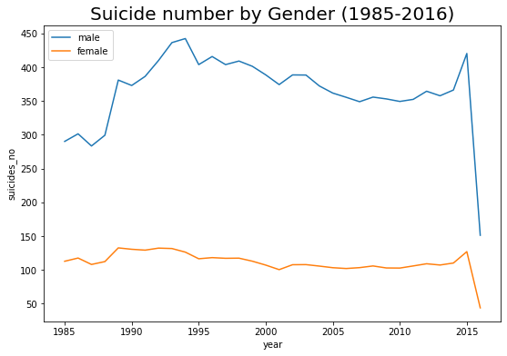

```python
df_men = df[df.sex == 'male']
df_women = df[df.sex == 'female']
plt.figure(figsize=(9,6))
plt.title('Suicide number by Gender (1985-2016)', fontsize=20)
sns.lineplot(df_men.year, df.suicides_no, ci = None)
sns.lineplot(df_women.year, df.suicides_no, ci = None)
plt.legend(["male", 'female'])
plt.show()
```

### Age

From this plot below, we see that as age gets higher, the suicide rate is also getting higher. With people of age 75+ having a significant higher suicide rate than the rest of the population in 1990, one can make some observation about the society at the time. In 1990, old people might have poor welfare programs supported by the government and since they are retired, they don't have a very stable income source. Another possibility is that people might want to decide their own death then to slowly lose their bodily function and die painfully. By any means, age is definitly one factor we should look into.

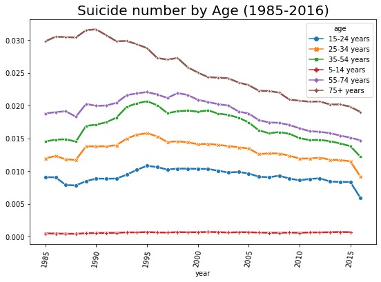

```python
df_age = df.groupby(["year","age"])["suicides_no","population"].sum()
df_reset = df_age.copy().reset_index()
plt.figure(figsize=(9,6))
plt.title('Suicide number by Age (1985-2016)', fontsize=20)
sns.lineplot("year", df_reset.suicides_no*100/df_reset.population, hue = "age",
             data = df_reset, linewidth = 2.5, style = "age", markers=True
            , dashes=False)
plt.xticks(rotation = 80)
plt.show()
```

Let's look at actual suicide count to see if we can get a clearer picture at the relationship between age and suicide. Here we see that even though people of age 75+ has a very high suicide rate. The amount of suicide that actually happened in very low. Addtionally, people of the age 35-54 has the highest amount of suicide. This align with our previous observations that male population has more responsibilities so it's more likely for them to snap under pressure. This number make sense because people between the age 35 to 54 is the age range where a man has to advance their professional career and start their own family, both contributes towards push one to the edge of committing suicide.

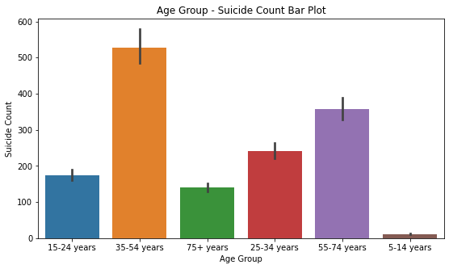

```python
plt.figure(figsize=(9,5))
sns.barplot(x=df['age'], y=df['suicides_no'])
plt.xlabel('Age Group')
plt.ylabel('Suicide Count')
plt.title('Age Group - Suicide Count Bar Plot')
plt.show()
```

### Generations

Every decade has its own struggle. Whether societal or financial, these struggles creates a big environment that contributes heavily to the well being of the people. In an age of desperation, more people will be driven to commit suicide than those that lived under prosperity. I suspect that the sucide rate between generations will show some insights as to the role that big envrionments like world economic and culture play in suicide rate.

```python
data_generation =  df.groupby('generation', as_index=False)['suicides_no'].sum().sort_values(by='suicides_no', ascending=False)
data_generation
```

|  | generation | suicides_no |
| --- | --- | --- |
| 0 | Boomers | 2284498 |
| 5 | Silent | 1781744 |
| 2 | Generation X | 1532804 |
| 4 | Millenials | 623459 |
| 1 | G.I. Generation | 510009 |
| 3 | Generation Z | 15906 |

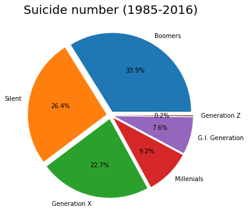

```python
plt.figure(figsize=(6,6))
plt.title('Suicide number (1985-2016)', fontsize=20)
plt.pie(data_generation.suicides_no, explode =(0.05, 0.05, 0.05, 0.05, 0.05, 0.05), labels=data_generation.generation, autopct='%1.1f%%')
plt.show()
```

From the pie chart above, we can see that the Boomers has the highest suicide rate of 33.9% and the Silent generation and Generation X had the second and third highest suicide rate. Generation Z had a very low percentages but that's because the Generation Z is too young for the time of this study.

### Country

Now let's look at the difference counties make in regards to the suicide rate of their citizens. This is a important factor because the society plays a major role in how well the people of their country is living. If a country is doing poorly, it's the citizens that suffer the most, thus resulting in a higher suicide count. First, let's make a list of all the countires to see this visually.

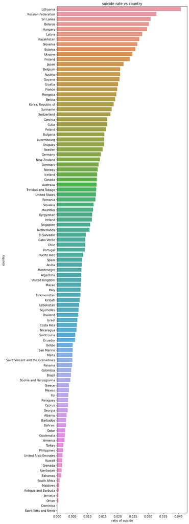

```python
df1 = df.groupby("country")["suicides_no"].sum()
country_name = list(df1.index.get_level_values(0))
countries = {}
for country in pycountry.countries:
    countries[country.name] = country.alpha_3

country_not_in_list = [i for i in country_name[:] if i not in countries.keys()]
country_not_in_list
#Corresponding the country names with respect to the code
df.replace("Republic of Korea", "Korea, Republic of", inplace = True)
df.replace('Czech Republic', "Czechia", inplace = True)
df.replace('Macau', 'Macao', inplace = True)
df.replace('Saint Vincent and Grenadines', "Saint Vincent and the Grenadines", inplace = True)

#Before ploting the suicide rate of each countries,
#we calcuate the suicide rate for each year, and then take the average of number as rate.
df_suino = df.groupby(["country","year"])["suicides_no"].sum()
df_sum = df_suino.sort_index(ascending=True)[:] * 100

df_pop = df.groupby(["country","year"]).population.sum()
df_pop_sum = df_pop.sort_index(ascending=False)[:]

df_total = df_sum / df_pop_sum

country_dict={}
for country in df_total.index.get_level_values(0):
    if country not in country_dict.keys():
        country_dict[country] = df_total[country].mean()
    else:
        pass

tup = list(country_dict.items())
tup.sort(key= lambda pair:pair[1], reverse = True)

country_list = [a[0] for a in tup]
country_suicide = [a[1] for a in tup]

plt.figure(figsize=(8,32))
sns.barplot(x=country_suicide[:],y=country_list[:])
plt.xlabel("ratio of suicide")
plt.ylabel("country")
plt.title("suicide rate vs country")
plt.show()
```

From this chart, we see that Lithuania has the highest suicide rate, followed by Russia Federation and Sri Lanka.

# Hypotehsis testing

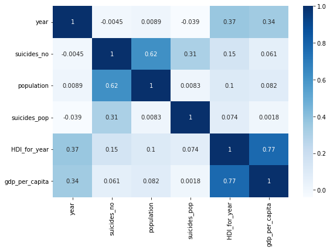

```python
plt.figure(figsize=(9,6))
sns.heatmap(df.corr(), annot=True, cmap='Blues')
plt.show()
```

# Machine Learning

In this section, I will attempt to create a algorithm that study from the dataset we have and make prediction about data that are unseen before. I will need to be able to correlate different attributes and understand how they are related. Since a lot of the HDI is null, we will drop these values as they might cause inaccuratcy in our predictions. I will also drop the country-year column as they are just respeated data. I will also make some change to the format of the colume for better readability, as well as spliting the data.

```python
df = df.drop(['HDI_for_year'], axis = 1)
df = df.drop(['country-year'], axis = 1)
df.shape
```

```
(27820, 10)
```

```python
df['gdp_for_year'] = df['gdp_for_year'].str.replace(',','').astype(float)
```

```python
#encoding the categorical features with LabelEncoder
categorical = ['country', 'year','age', 'sex', 'generation']
le = sklearn.preprocessing.LabelEncoder()

for column in categorical:
    df[column] = le.fit_transform(df[column])
```

```python
numerical = ['suicides_no', 'population', 'suicides_pop',
              'gdp_for_year','gdp_per_capita']

rc = RobustScaler()
df[numerical] = rc.fit_transform(df[numerical])
```

```python
# Sepratating & assigning features and target columns to X & y

y = df['suicides_pop']
X = df.drop('suicides_pop',axis=1)
X.shape, y.shape
```

```
((27820, 9), (27820,))
```

```python
from sklearn.model_selection import train_test_split

X_train, X_test, y_train, y_test = train_test_split(X, y, test_size = 0.2, random_state = 12)
X_train.shape, X_test.shape
```

```
((22256, 9), (5564, 9))
```

## Linear Regression

In this section, I will use to finds the parameters w and b that minimize the mean squared error between predictions and the true regression targets, y, on the training set.

```python
from sklearn.metrics import mean_squared_error
# instantiate the model
lr = LinearRegression()
# fit the model
lr.fit(X_train, y_train)

#predicting the target value from the model for the samples
y_test_lr = lr.predict(X_test)
y_train_lr = lr.predict(X_train)

#computing the accuracy of the model performance
acc_train_lr = lr.score(X_train, y_train)
acc_test_lr = lr.score(X_test, y_test)

#computing root mean squared error (RMSE)
rmse_train_lr = np.sqrt(mean_squared_error(y_train, y_train_lr))
rmse_test_lr = np.sqrt(mean_squared_error(y_test, y_test_lr))

print("Linear Regression: Accuracy on training Data: {:.3f}".format(acc_train_lr))
print("Linear Regression: Accuracy on test Data: {:.3f}".format(acc_test_lr))
print('\nLinear Regression: The RMSE of the training set is:', rmse_train_lr)
print('Linear Regression: The RMSE of the testing set is:', rmse_test_lr)
```

```
Linear Regression: Accuracy on training Data: 0.288
Linear Regression: Accuracy on test Data: 0.296

Linear Regression: The RMSE of the training set is: 1.0132743046913395
Linear Regression: The RMSE of the testing set is: 1.0373462826999316
```

```
0.2876036397457422
```

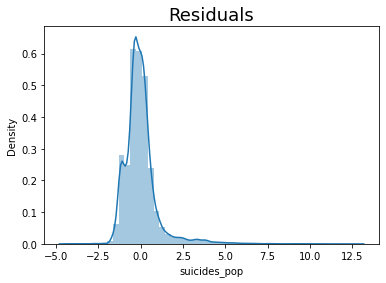

```python
y_hat = lr.predict(X_train)
sns.distplot(y_train - y_hat)
plt.title("Residuals", size=18)
lr.score(X_train,y_train)
```

Since the accuracy on the training set is only 0.288, this is not a very good model. Next we will try with Decision Tree.

## Decision Tree

Decision Tree learns hierarchies of if/else statements and eventually arrives at a decision. In machine learning, these if/else statements are called tests. This algorithem searches for all possible tests and find the ones that are most informative about our variable.

```python
from sklearn.tree import DecisionTreeRegressor

# instantiate the model
tree = DecisionTreeRegressor(max_depth=9)
# fit the model
tree.fit(X_train, y_train)

#predicting the target value from the model for the samples
y_test_tree = tree.predict(X_test)
y_train_tree = tree.predict(X_train)

#computing the accuracy of the model performance
acc_train_tree = tree.score(X_train, y_train)
acc_test_tree = tree.score(X_test, y_test)

#computing root mean squared error (RMSE)
rmse_train_tree = np.sqrt(mean_squared_error(y_train, y_train_tree))
rmse_test_tree = np.sqrt(mean_squared_error(y_test, y_test_tree))

print("Decision Tree: Accuracy on training Data: {:.3f}".format(acc_train_tree))
print("Decision Tree: Accuracy on test Data: {:.3f}".format(acc_test_tree))
print('\nDecision Tree: The RMSE of the training set is:', rmse_train_tree)
print('Decision Tree: The RMSE of the testing set is:', rmse_test_tree)
```

```
Decision Tree: Accuracy on training Data: 0.967
Decision Tree: Accuracy on test Data: 0.952

Decision Tree: The RMSE of the training set is: 0.21965355867472552
Decision Tree: The RMSE of the testing set is: 0.27097974322623736
```

# Conclusion